# STOR 767 HW 3 - Computing

Brian N. White

10/27/2021

# Problem: IQ and successes

## Background: Measurement of Intelligence

Case Study: How intelligence relates to one’s future successes?

**Data needed: `IQ.Full.csv`**

ASVAB (Armed Services Vocational Aptitude Battery) tests have been used as a screening test for those who want to join the army or other jobs.

Our data set `IQ.csv` is a subset of individuals from the 1979 National Longitudinal Study of Youth (NLSY79) survey who were re-interviewed in 2006. Information about family, personal demographic such as gender, race and education level, plus a set of ASVAB (Armed Services Vocational Aptitude Battery) test scores are available. It is STILL used as a screening test for those who want to join the army! ASVAB scores were 1981 and income was 2005.

**Our goals:**

- Is IQ related to one’s successes measured by Income?
- Is there evidence to show that Females are under-paid?
- What are the best possible prediction models to predict future income?

**The ASVAB has the following components:**

- Science, Arith (Arithmetic reasoning), Word (Word knowledge), Parag (Paragraph comprehension), Numer (Numerical operation), Coding (Coding speed), Auto (Automative and Shop information), Math (Math knowledge), Mechanic (Mechanic Comprehension) and Elec (Electronic information).
- AFQT (Armed Forces Qualifying Test) is a combination of Word, Parag, Math and Arith.
- Note: Service Branch requirement: Army 31, Navy 35, Marines 31, Air Force 36, and Coast Guard 45,(out of 100 which is the max!)

**The detailed variable definitions:**

Personal Demographic Variables:

- Race: 1 = Hispanic, 2 = Black, 3 = Not Hispanic or Black
- Gender: a factor with levels “female” and “male”
- Educ: years of education completed by 2006

Household Environment:

- Imagazine: a variable taking on the value 1 if anyone in the respondent?™s household regularly read magazines in 1979, otherwise 0
- Inewspaper: a variable taking on the value 1 if anyone in the respondent?™s household regularly read newspapers in 1979, otherwise 0
- Ilibrary: a variable taking on the value 1 if anyone in the respondent?™s household had a library card in 1979, otherwise 0
- MotherEd: mother’s years of education
- FatherEd: father’s years of education

Variables Related to ASVAB test Scores in 1981 (Proxy of IQ’s)

- AFQT: percentile score on the AFQT intelligence test in 1981
- Coding: score on the Coding Speed test in 1981
- Auto: score on the Automotive and Shop test in 1981
- Mechanic: score on the Mechanic test in 1981
- Elec: score on the Electronics Information test in 1981
- Science: score on the General Science test in 1981
- Math: score on the Math test in 1981
- Arith: score on the Arithmetic Reasoning test in 1981
- Word: score on the Word Knowledge Test in 1981
- Parag: score on the Paragraph Comprehension test in 1981
- Numer: score on the Numerical Operations test in 1981

Variable Related to Life Success in 2006

- Income2005: total annual income from wages and salary in 2005. We will use a natural log transformation over the income.

The following 10 questions are answered as 1: strongly agree, 2: agree, 3: disagree, 4: strongly disagree

- Esteem 1: I am a person of worth?
- Esteem 2: I have a number of good qualities?
- Esteem 3: I am inclined to feel like a failure?
- Esteem 4: I do things as well as others?
- Esteem 5: I do not have much to be proud of?
- Esteem 6: I take a positive attitude towards myself and others?
- Esteem 7: I am satisfied with myself?
- Esteem 8: I wish I could have more respect for myself?
- Esteem 9: I feel useless at times?
- Esteem 10: I think I am no good at all?

**Note: we will not use the Esteem scores in this homework.**

## 1. EDA

1. Make a few informative tables or plots to see how intelligence might relate to the log income.
2. Make a training data and testing data (approximately 2/3 observations as training data)

**Solution**

**i**

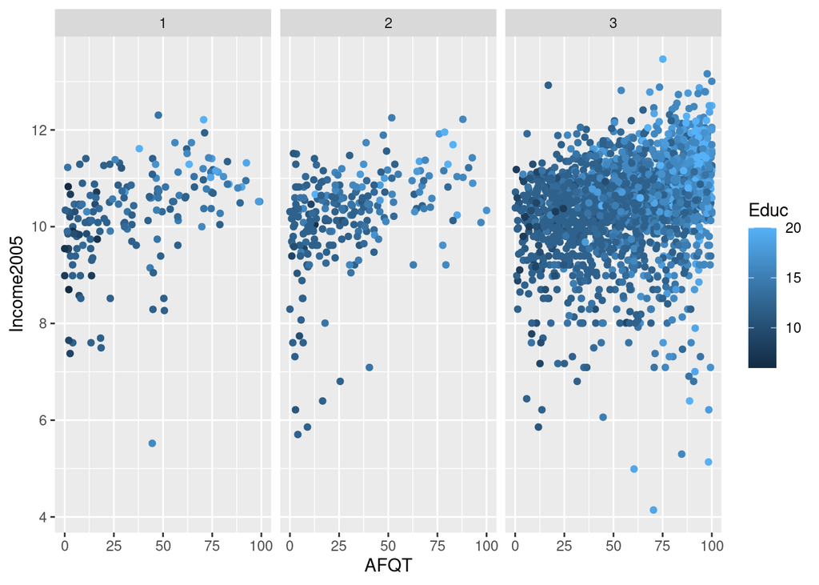

```r
iq %>%
  ggplot(aes(AFQT, Income2005, col=Educ)) +
  geom_point() +
  facet_wrap(~Race)
```

```r
iq %>%
  group_by(Race) %>%
  summarize(n=n(), proportion=n()/2584)
```

| Race | n | proportion |
| --- | --- | --- |
| 1 | 165 | 0.06385449 |
| 2 | 237 | 0.09171827 |
| 3 | 2182 | 0.84442724 |

**ii**

```r
set.seed(5)
#generate training data indices
iq_train_index <- sample(nrow(iq), (2/3)*nrow(iq))
#generate training data with 2/3 of original observations
iq_train <- iq[iq_train_index,]
#generate testing data from the left over observations
iq_test <- iq[-iq_train_index,]
```

## 2. Single trees

1. Build a reasonable single tree using all the variables to predict log income. Display the tree.
2. Explain the predictions. Does that agree with our intuition?
3. Can you detect gender bias against women from the tree built?
4. Do we have evidence that the high IQs result in higher income? What is the testing error for the tree you built?

**Solution**

**i**

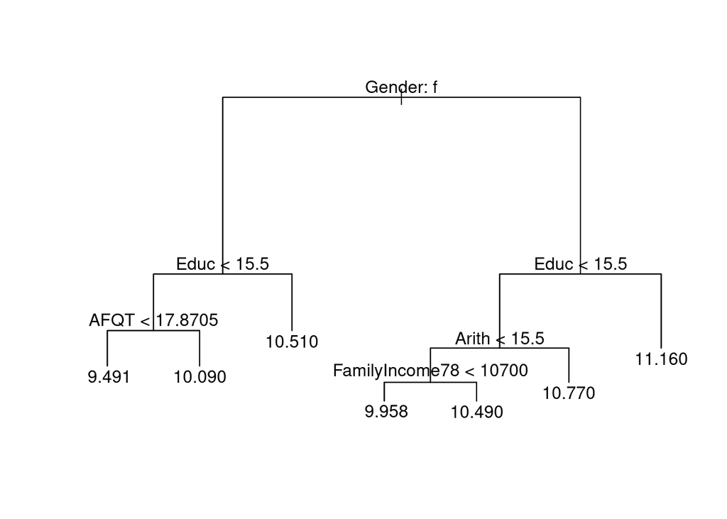

```r
tree_train <- tree(Income2005~., iq_train)
plot(tree_train)
text(tree_train, pretty = 1)
```

**iv**

```r
tree_test <- predict(tree_train, iq_test)

#testing error (MSE), note denominator is n - (# of terminal nodes)
tree_test_err <- sum((iq_test$Income2005-tree_test)^2)/855
tree_test_err
```

```
## [1] 0.7909431
```

## 3. Bagging with two bootstrap trees.

1. Build and display two bootstrap trees. Commenting on the differences among the two trees.
2. Bag the twos tree by taking average of the two bootstrap trees above. What is the testing error?

**Solution**

**i**

```r
set.seed(5)
#generate two bootstrap samples
sample.df <- function(df){
  index <- sample(nrow(df), nrow(df), replace=T)
  sample <- df[index,]
  return(sample)
}

boot1 <- sample.df(iq_train)
boot2 <- sample.df(iq_train)

#generate two bootstrap trees
tree_boot1<- tree(Income2005~., boot1)
tree_boot2<- tree(Income2005~., boot2)

#summary of trees
summary(tree_boot1)
```

```
##
## Regression tree:
## tree(formula = Income2005 ~ ., data = boot1)
## Variables actually used in tree construction:
## [1] "Gender"         "AFQT"           "Coding"         "Mechanic"
## [5] "Educ"           "FamilyIncome78" "Arith"          "Numer"
## Number of terminal nodes:  10
## Residual mean deviance:  0.6358 = 1089 / 1712
## Distribution of residuals:
##     Min.  1st Qu.   Median     Mean  3rd Qu.     Max.
## -6.81300 -0.35960  0.07866  0.00000  0.45570  2.74300
```

```r
summary(tree_boot2)
```

```
##
## Regression tree:
## tree(formula = Income2005 ~ ., data = boot2)
## Variables actually used in tree construction:
## [1] "Arith"  "Word"   "Gender" "Numer"  "Educ"   "Coding"
## Number of terminal nodes:  9
## Residual mean deviance:  0.6904 = 1183 / 1713
## Distribution of residuals:
##    Min. 1st Qu.  Median    Mean 3rd Qu.    Max.
## -4.6660 -0.3944  0.1145  0.0000  0.5197  2.5190
```

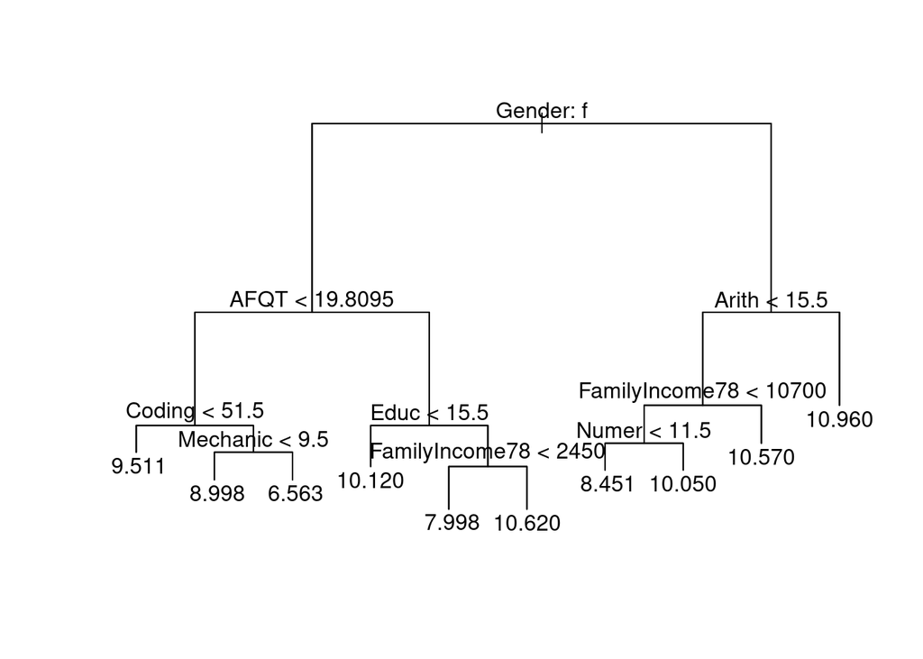

```r
#display the two bootstrap trees
plot(tree_boot1)
text(tree_boot1, pretty = 1)
```

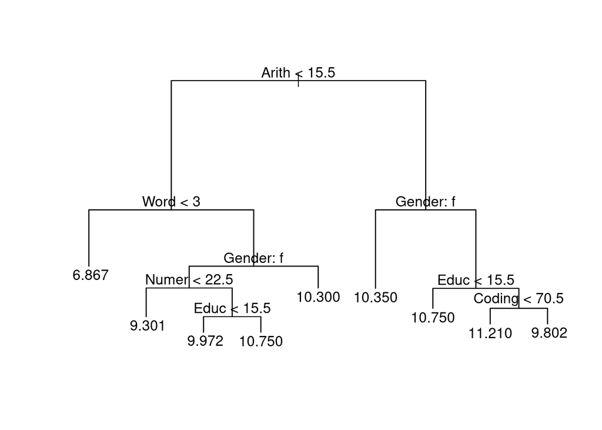

```r
plot(tree_boot2)
text(tree_boot2, pretty = 1)
```

**ii**

```r
#compute the test predictions for each tree
tree_boot1_test <- predict(tree_boot1, iq_test)
tree_boot2_test <- predict(tree_boot2, iq_test)

#bag the trees by taking the average of their respective test data predictions
bagged_predictions <- (tree_boot1_test + tree_boot2_test)/2

#compute testing error (MSE) for bagged tree predictions
bagged_test_err <- sum((iq_test$Income2005-bagged_predictions)^2)/852
bagged_test_err
```

```
## [1] 0.8247863
```

## 4. Build the best possible random forest

1. Show the process how you tune the number of the trees and `mtry`
2. What is the testing error for your random forest?
3. Comment on the pro and cons for the random forest comparing with the single tree you built earlier.